# CE Assignment 1

# a) For each predictor, fit a simple linear regression model to predict the response. Describe your results. In which of the models is there a statistically significant association between the predictor and the response? Create some plots to back up your assertions.

```r
summary(lm(crim~zn, data=Boston))
```

```
##
## Call:
## lm(formula = crim ~ zn, data = Boston)
##
## Residuals:
##    Min     1Q Median     3Q    Max
## -4.429 -4.222 -2.620  1.250 84.523
##
## Coefficients:
##             Estimate Std. Error t value Pr(>|t|)
## (Intercept)  4.45369    0.41722  10.675  < 2e-16 ***
## zn          -0.07393    0.01609  -4.594 5.51e-06 ***
## ---
## Signif. codes:  0 '***' 0.001 '**' 0.01 '*' 0.05 '.' 0.1 ' ' 1
##
## Residual standard error: 8.435 on 504 degrees of freedom
## Multiple R-squared:  0.04019,    Adjusted R-squared:  0.03828
## F-statistic:  21.1 on 1 and 504 DF,  p-value: 5.506e-06
```

```r
attach(Boston)
```

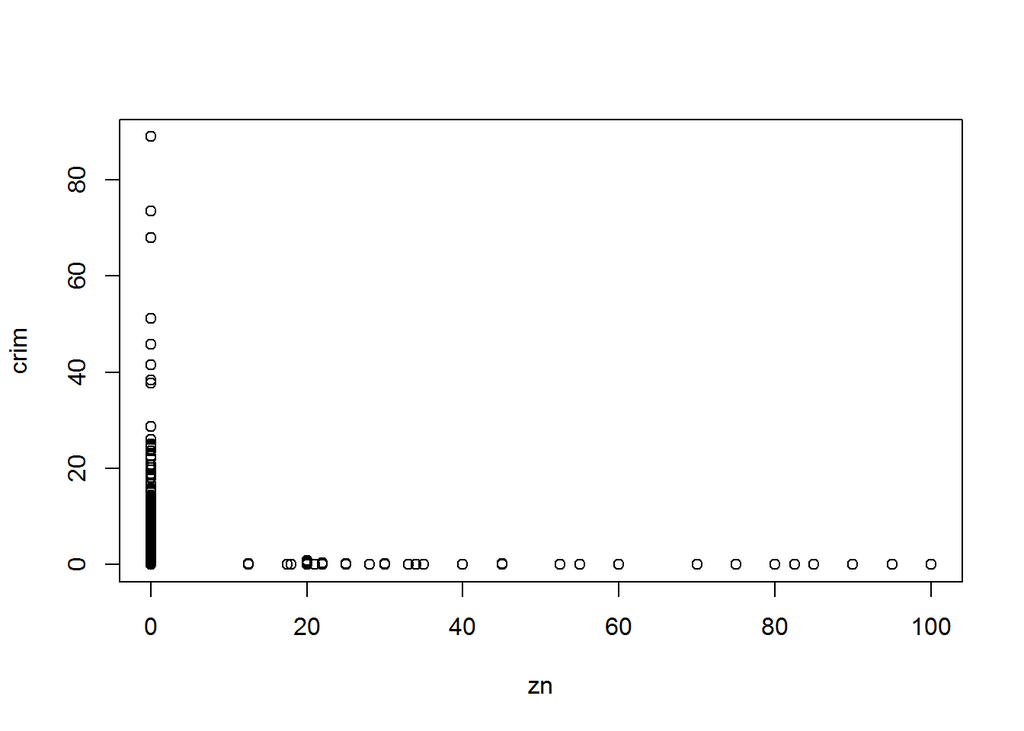

```r
plot(zn,crim)
```

```r
zncoef <- coef(summary(lm(crim~zn, data=Boston)))

summary(lm(crim~indus, data=Boston))
```

```
##
## Call:
## lm(formula = crim ~ indus, data = Boston)
##
## Residuals:
##     Min      1Q  Median      3Q     Max
## -11.972  -2.698  -0.736   0.712  81.813
##
## Coefficients:
##             Estimate Std. Error t value Pr(>|t|)
## (Intercept) -2.06374    0.66723  -3.093  0.00209 **
## indus        0.50978    0.05102   9.991  < 2e-16 ***
## ---
## Signif. codes:  0 '***' 0.001 '**' 0.01 '*' 0.05 '.' 0.1 ' ' 1
##
## Residual standard error: 7.866 on 504 degrees of freedom
## Multiple R-squared:  0.1653, Adjusted R-squared:  0.1637
## F-statistic: 99.82 on 1 and 504 DF,  p-value: < 2.2e-16
```

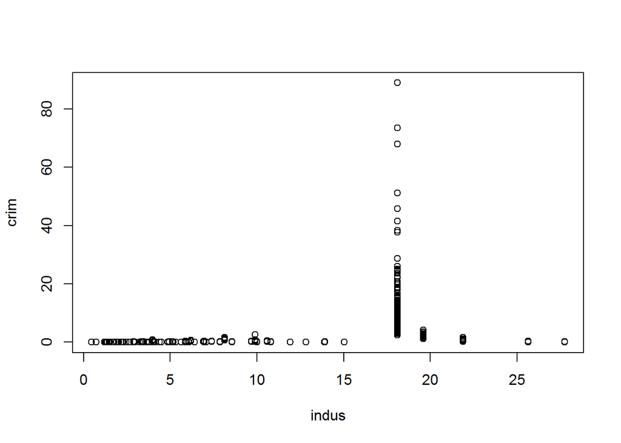

```r
plot(indus,crim)
```

```r
induscoef <- coef(summary(lm(crim~indus, data=Boston)))

summary(lm(crim~chas, data=Boston))
```

```
##
## Call:
## lm(formula = crim ~ chas, data = Boston)
##
## Residuals:
##    Min     1Q Median     3Q    Max
## -3.738 -3.661 -3.435  0.018 85.232
##
## Coefficients:
##             Estimate Std. Error t value Pr(>|t|)
## (Intercept)   3.7444     0.3961   9.453   <2e-16 ***
## chas         -1.8928     1.5061  -1.257    0.209
## ---
## Signif. codes:  0 '***' 0.001 '**' 0.01 '*' 0.05 '.' 0.1 ' ' 1
##
## Residual standard error: 8.597 on 504 degrees of freedom
## Multiple R-squared:  0.003124,   Adjusted R-squared:  0.001146
## F-statistic: 1.579 on 1 and 504 DF,  p-value: 0.2094
```

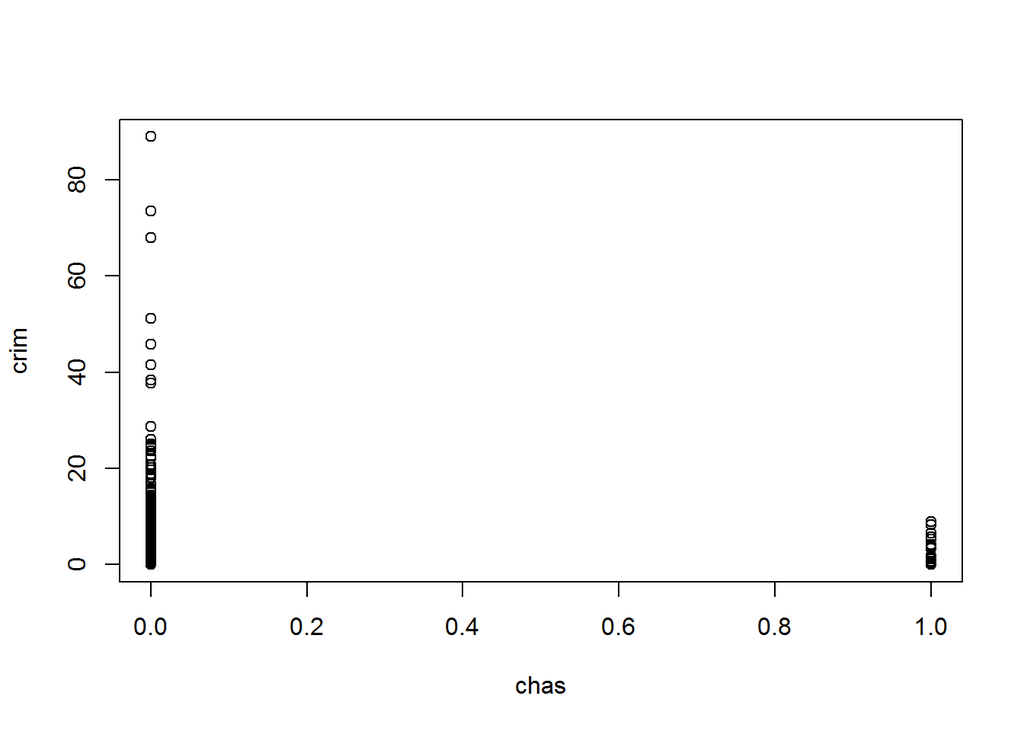

```r
plot(chas,crim)
```

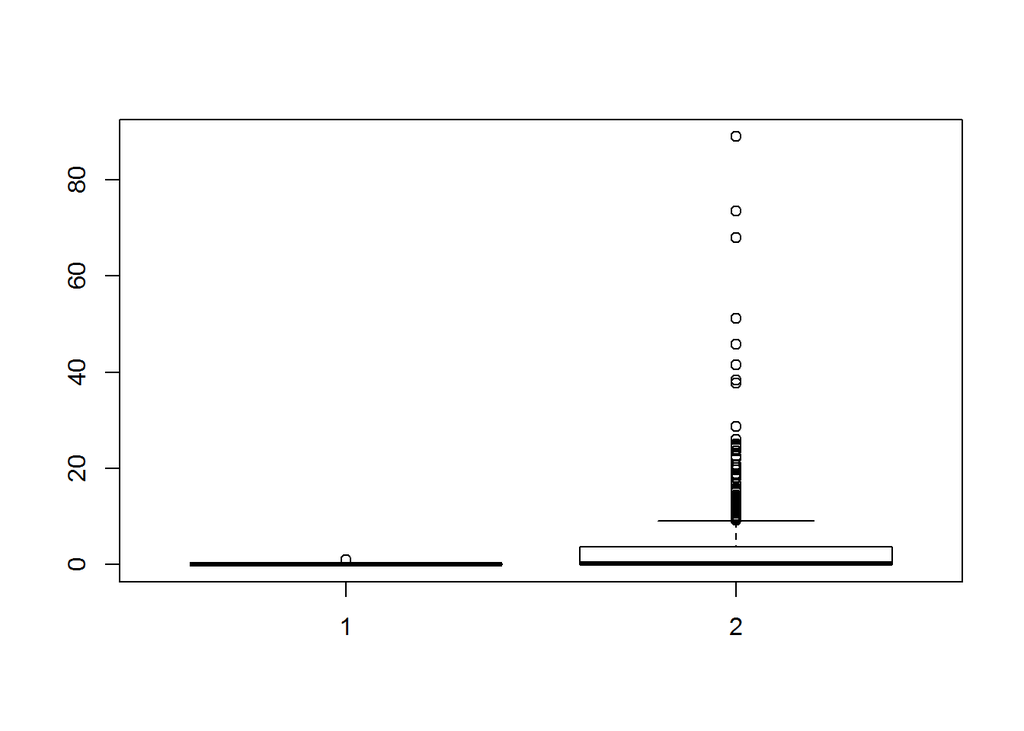

```r
chascoef <- coef(summary(lm(crim~chas, data=Boston)))
boxplot(chas,crim)
```

```r
summary(lm(crim~nox, data=Boston))
```

```
##
## Call:
## lm(formula = crim ~ nox, data = Boston)
##
## Residuals:
##     Min      1Q  Median      3Q     Max
## -12.371  -2.738  -0.974   0.559  81.728
##
## Coefficients:
##             Estimate Std. Error t value Pr(>|t|)
## (Intercept)  -13.720      1.699  -8.073 5.08e-15 ***
## nox           31.249      2.999  10.419  < 2e-16 ***
## ---
## Signif. codes:  0 '***' 0.001 '**' 0.01 '*' 0.05 '.' 0.1 ' ' 1
##
## Residual standard error: 7.81 on 504 degrees of freedom
## Multiple R-squared:  0.1772, Adjusted R-squared:  0.1756
## F-statistic: 108.6 on 1 and 504 DF,  p-value: < 2.2e-16
```

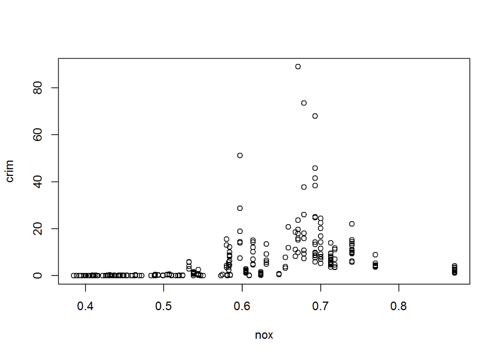

```r
plot(nox,crim)
```

```r
noxcoef <- coef(summary(lm(crim~nox, data=Boston)))

summary(lm(crim~rm, data=Boston))
```

```
##
## Call:
## lm(formula = crim ~ rm, data = Boston)
##
## Residuals:
##    Min     1Q Median     3Q    Max
## -6.604 -3.952 -2.654  0.989 87.197
##
## Coefficients:
##             Estimate Std. Error t value Pr(>|t|)
## (Intercept)   20.482      3.365   6.088 2.27e-09 ***
## rm            -2.684      0.532  -5.045 6.35e-07 ***
## ---
## Signif. codes:  0 '***' 0.001 '**' 0.01 '*' 0.05 '.' 0.1 ' ' 1
##
## Residual standard error: 8.401 on 504 degrees of freedom
## Multiple R-squared:  0.04807,    Adjusted R-squared:  0.04618
## F-statistic: 25.45 on 1 and 504 DF,  p-value: 6.347e-07
```

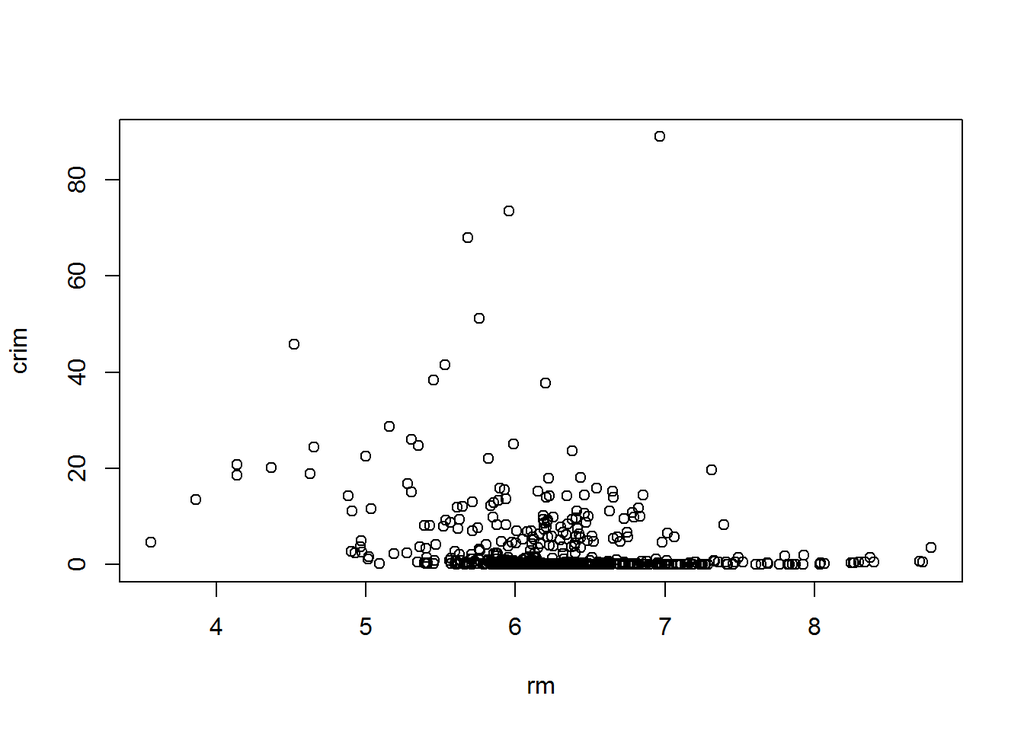

```r
plot(rm, crim)
```

```r
rmcoef <- coef(summary(lm(crim~rm, data=Boston)))

summary(lm(crim~age, data=Boston))
```

```
##
## Call:
## lm(formula = crim ~ age, data = Boston)
##
## Residuals:
##    Min     1Q Median     3Q    Max
## -6.789 -4.257 -1.230  1.527 82.849
##
## Coefficients:
##             Estimate Std. Error t value Pr(>|t|)
## (Intercept) -3.77791    0.94398  -4.002 7.22e-05 ***
## age          0.10779    0.01274   8.463 2.85e-16 ***
## ---
## Signif. codes:  0 '***' 0.001 '**' 0.01 '*' 0.05 '.' 0.1 ' ' 1
##
## Residual standard error: 8.057 on 504 degrees of freedom
## Multiple R-squared:  0.1244, Adjusted R-squared:  0.1227
## F-statistic: 71.62 on 1 and 504 DF,  p-value: 2.855e-16
```

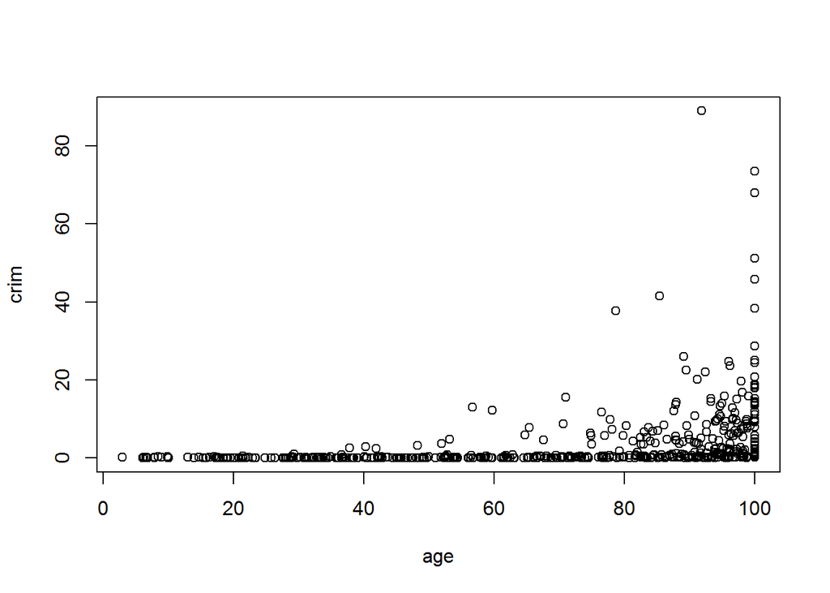

```r
plot(age,crim)
```

```r
agecoef <- coef(summary(lm(crim~age, data=Boston)))

summary(lm(crim~dis, data=Boston))
```

```
##
## Call:
## lm(formula = crim ~ dis, data = Boston)
##
## Residuals:
##    Min     1Q Median     3Q    Max
## -6.708 -4.134 -1.527  1.516 81.674
##
## Coefficients:
##             Estimate Std. Error t value Pr(>|t|)
## (Intercept)   9.4993     0.7304  13.006   <2e-16 ***
## dis          -1.5509     0.1683  -9.213   <2e-16 ***
## ---
## Signif. codes:  0 '***' 0.001 '**' 0.01 '*' 0.05 '.' 0.1 ' ' 1
##
## Residual standard error: 7.965 on 504 degrees of freedom
## Multiple R-squared:  0.1441, Adjusted R-squared:  0.1425
## F-statistic: 84.89 on 1 and 504 DF,  p-value: < 2.2e-16
```

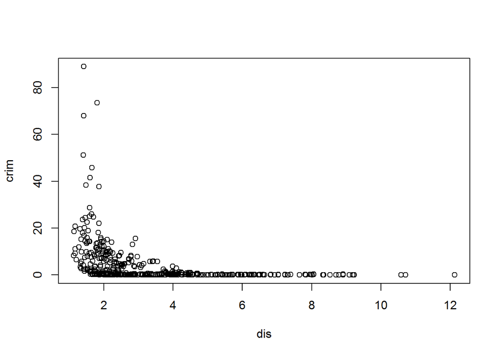

```r
plot(dis,crim)
```

```r
discoef <- coef(summary(lm(crim~dis, data=Boston)))

summary(lm(crim~rad, data=Boston))
```

```
##
## Call:
## lm(formula = crim ~ rad, data = Boston)
##
## Residuals:
##     Min      1Q  Median      3Q     Max
## -10.164  -1.381  -0.141   0.660  76.433
##
## Coefficients:
##             Estimate Std. Error t value Pr(>|t|)
## (Intercept) -2.28716    0.44348  -5.157 3.61e-07 ***
## rad          0.61791    0.03433  17.998  < 2e-16 ***
## ---
## Signif. codes:  0 '***' 0.001 '**' 0.01 '*' 0.05 '.' 0.1 ' ' 1
##
## Residual standard error: 6.718 on 504 degrees of freedom
## Multiple R-squared:  0.3913, Adjusted R-squared:   0.39
## F-statistic: 323.9 on 1 and 504 DF,  p-value: < 2.2e-16
```

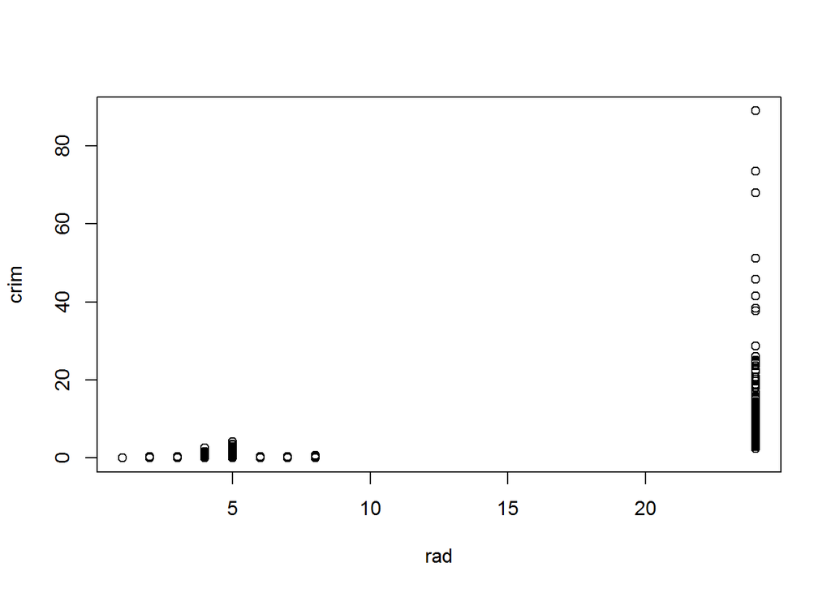

```r
plot(rad,crim)
```

```r
radcoef <- coef(summary(lm(crim~rad, data=Boston)))

summary(lm(crim~tax, data=Boston))
```

```
##
## Call:
## lm(formula = crim ~ tax, data = Boston)
##
## Residuals:
##     Min      1Q  Median      3Q     Max
## -12.513  -2.738  -0.194   1.065  77.696
##
## Coefficients:
##              Estimate Std. Error t value Pr(>|t|)
## (Intercept) -8.528369   0.815809  -10.45   <2e-16 ***
## tax          0.029742   0.001847   16.10   <2e-16 ***
## ---
## Signif. codes:  0 '***' 0.001 '**' 0.01 '*' 0.05 '.' 0.1 ' ' 1
##
## Residual standard error: 6.997 on 504 degrees of freedom
## Multiple R-squared:  0.3396, Adjusted R-squared:  0.3383
## F-statistic: 259.2 on 1 and 504 DF,  p-value: < 2.2e-16
```

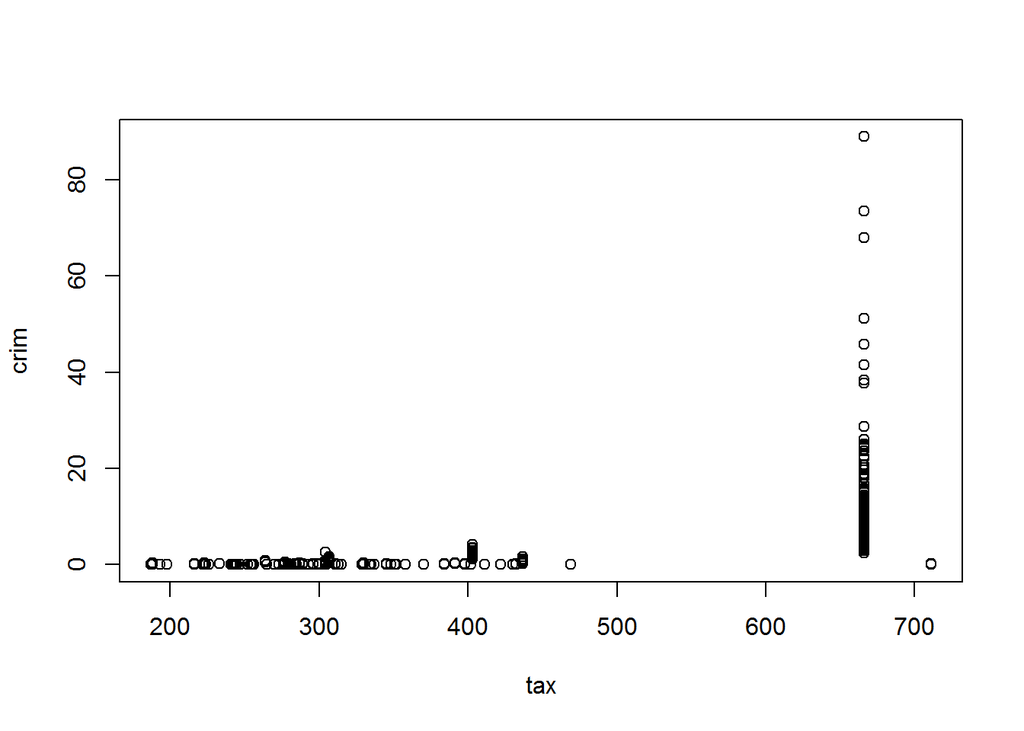

```r
plot(tax,crim)
```

```r
taxcoef <- coef(summary(lm(crim~tax, data=Boston)))

summary(lm(crim~ptratio, data=Boston))
```

```
##
## Call:
## lm(formula = crim ~ ptratio, data = Boston)
##
## Residuals:
##    Min     1Q Median     3Q    Max
## -7.654 -3.985 -1.912  1.825 83.353
##
## Coefficients:
##             Estimate Std. Error t value Pr(>|t|)
## (Intercept) -17.6469     3.1473  -5.607 3.40e-08 ***
## ptratio       1.1520     0.1694   6.801 2.94e-11 ***
## ---
## Signif. codes:  0 '***' 0.001 '**' 0.01 '*' 0.05 '.' 0.1 ' ' 1
##
## Residual standard error: 8.24 on 504 degrees of freedom
## Multiple R-squared:  0.08407,    Adjusted R-squared:  0.08225
## F-statistic: 46.26 on 1 and 504 DF,  p-value: 2.943e-11
```

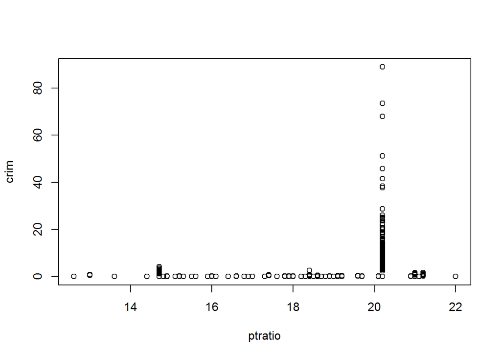

```r
plot(ptratio,crim)
```

```r
ptratiocoef <- coef(summary(lm(crim~ptratio, data=Boston)))

summary(lm(crim~black, data=Boston))
```

```
##
## Call:
## lm(formula = crim ~ black, data = Boston)
##
## Residuals:
##     Min      1Q  Median      3Q     Max
## -13.756  -2.299  -2.095  -1.296  86.822
##
## Coefficients:
##              Estimate Std. Error t value Pr(>|t|)
## (Intercept) 16.553529   1.425903  11.609   <2e-16 ***
## black       -0.036280   0.003873  -9.367   <2e-16 ***
## ---
## Signif. codes:  0 '***' 0.001 '**' 0.01 '*' 0.05 '.' 0.1 ' ' 1
##
## Residual standard error: 7.946 on 504 degrees of freedom
## Multiple R-squared:  0.1483, Adjusted R-squared:  0.1466
## F-statistic: 87.74 on 1 and 504 DF,  p-value: < 2.2e-16
```

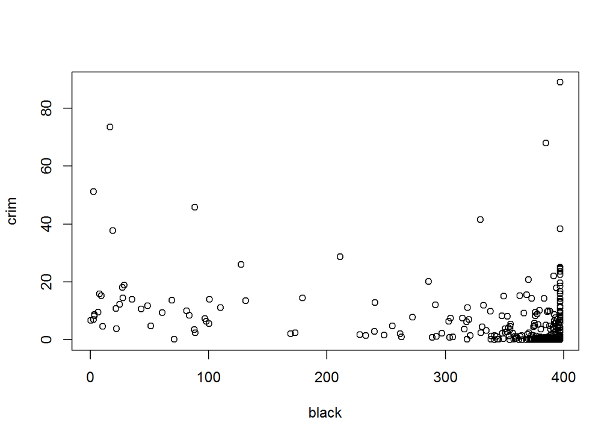

```r
plot(black,crim)
```

```r
blackcoef <- coef(summary(lm(crim~black, data=Boston)))

summary(lm(crim~lstat, data=Boston))
```

```
##
## Call:
## lm(formula = crim ~ lstat, data = Boston)
##
## Residuals:
##     Min      1Q  Median      3Q     Max
## -13.925  -2.822  -0.664   1.079  82.862
##
## Coefficients:
##             Estimate Std. Error t value Pr(>|t|)
## (Intercept) -3.33054    0.69376  -4.801 2.09e-06 ***
## lstat        0.54880    0.04776  11.491  < 2e-16 ***
## ---
## Signif. codes:  0 '***' 0.001 '**' 0.01 '*' 0.05 '.' 0.1 ' ' 1
##
## Residual standard error: 7.664 on 504 degrees of freedom
## Multiple R-squared:  0.2076, Adjusted R-squared:  0.206
## F-statistic:   132 on 1 and 504 DF,  p-value: < 2.2e-16
```

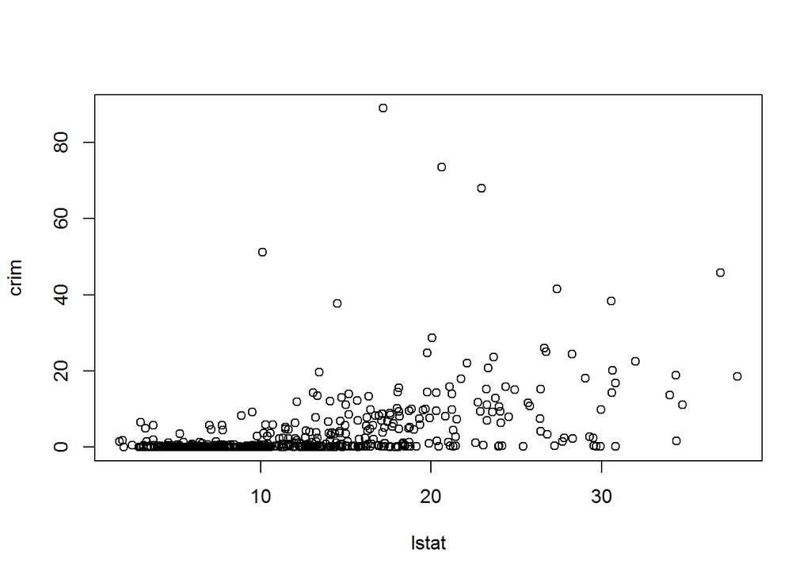

```r
plot(lstat,crim)
```

```r
lstatcoef <- coef(summary(lm(crim~lstat, data=Boston)))

summary(lm(crim~medv, data=Boston))
```

```
##
## Call:
## lm(formula = crim ~ medv, data = Boston)
##
## Residuals:
##    Min     1Q Median     3Q    Max
## -9.071 -4.022 -2.343  1.298 80.957
##
## Coefficients:
##             Estimate Std. Error t value Pr(>|t|)
## (Intercept) 11.79654    0.93419   12.63   <2e-16 ***
## medv        -0.36316    0.03839   -9.46   <2e-16 ***
## ---
## Signif. codes:  0 '***' 0.001 '**' 0.01 '*' 0.05 '.' 0.1 ' ' 1
##
## Residual standard error: 7.934 on 504 degrees of freedom
## Multiple R-squared:  0.1508, Adjusted R-squared:  0.1491
## F-statistic: 89.49 on 1 and 504 DF,  p-value: < 2.2e-16
```

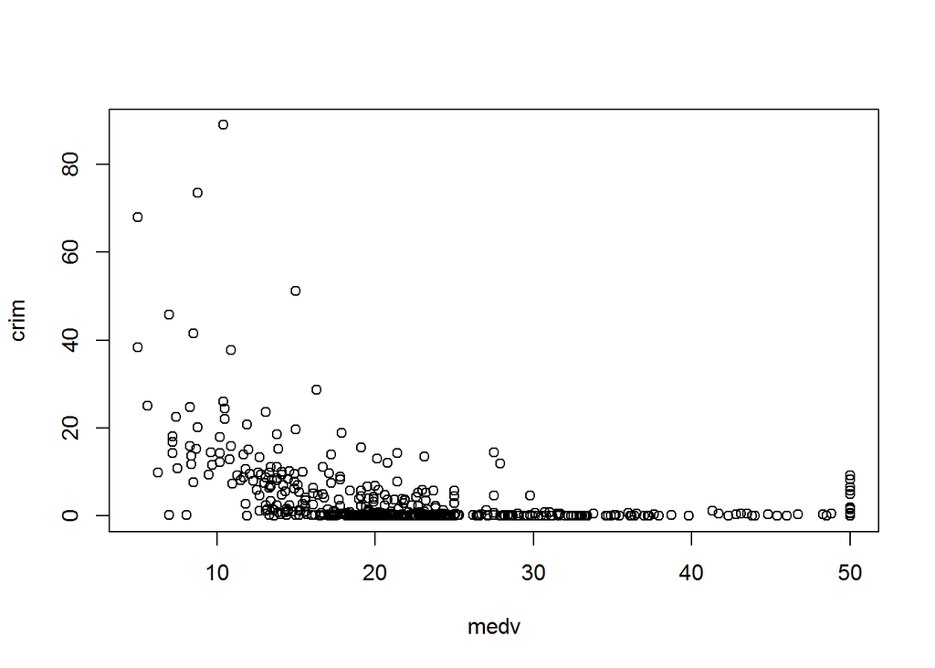

```r
plot(medv,crim)
```

```r
medvcoef <- coef(summary(lm(crim~medv, data=Boston)))
```

According to the p-values of each individual predictor, all but “chas” is a statistically significant predictor of crime rate when simple linear regressions for each predictor is done. “Chas,” however, is a qualitative predictor, so the 0’s and 1’s treated as numerics can be misleading. The plot for crim vs chas shows an association between being bound by the Charles River and crime rates. The plots for each predictor vs. crime rates show some association with crim with varying degrees.

# b) Fit a multiple regression model to predict the response using all of the predictors. Describe your results. For which predictors can we reject the null hypothesis H0 : B_j = 0?

```r
summary(lm(crim~., dat=Boston))
```

```
##
## Call:
## lm(formula = crim ~ ., data = Boston)
##
## Residuals:
##    Min     1Q Median     3Q    Max
## -9.924 -2.120 -0.353  1.019 75.051
##
## Coefficients:
##               Estimate Std. Error t value Pr(>|t|)
## (Intercept)  17.033228   7.234903   2.354 0.018949 *
## zn            0.044855   0.018734   2.394 0.017025 *
## indus        -0.063855   0.083407  -0.766 0.444294
## chas         -0.749134   1.180147  -0.635 0.525867
## nox         -10.313535   5.275536  -1.955 0.051152 .
## rm            0.430131   0.612830   0.702 0.483089
## age           0.001452   0.017925   0.081 0.935488
## dis          -0.987176   0.281817  -3.503 0.000502 ***
## rad           0.588209   0.088049   6.680 6.46e-11 ***
## tax          -0.003780   0.005156  -0.733 0.463793
## ptratio      -0.271081   0.186450  -1.454 0.146611
## black        -0.007538   0.003673  -2.052 0.040702 *
## lstat         0.126211   0.075725   1.667 0.096208 .
## medv         -0.198887   0.060516  -3.287 0.001087 **
## ---
## Signif. codes:  0 '***' 0.001 '**' 0.01 '*' 0.05 '.' 0.1 ' ' 1
##
## Residual standard error: 6.439 on 492 degrees of freedom
## Multiple R-squared:  0.454,  Adjusted R-squared:  0.4396
## F-statistic: 31.47 on 13 and 492 DF,  p-value: < 2.2e-16
```

# c) How do your results from (a) compare to your results from (b)? Create a plot displaying the univariate regression coefficients from (a) on the x-axis, and the multiple regression coefficients from (b) on the y-axis. That is, each predictor is displayed as a single point in the plot. Its coefficient in a simple linear regression model is shown on the x-axis, and its coefficient estimate in the multiple linear regression model is shown on the y-axis.

The results from b) were quite different from a) when all the predictors were factored into the model.

To plot all the regression coefficients, I had to store them into two separate objects first.

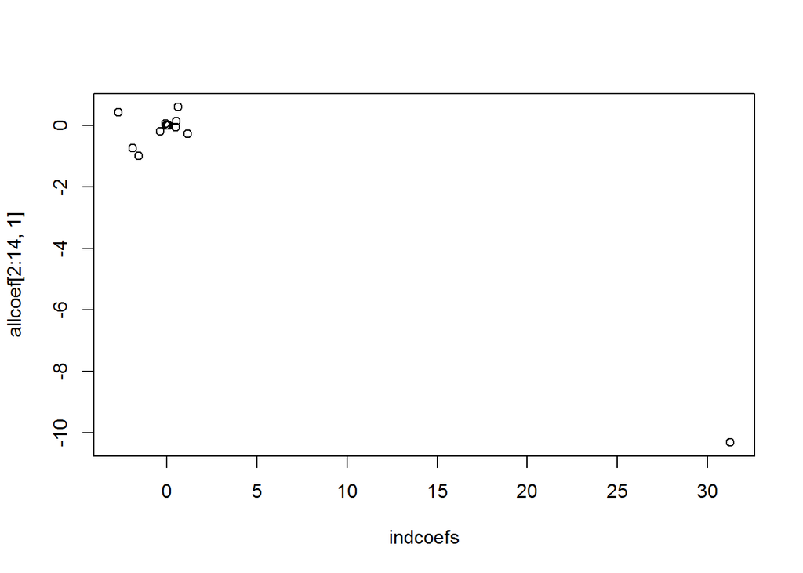

```r
allcoef <- coef(summary(lm(crim~., dat=Boston)))
indcoefs <- c(zncoef[2,1], induscoef[2,1], chascoef[2,1], noxcoef[2,1], rmcoef[2,1],agecoef[2,1],discoef[2,1],radcoef[2,1],taxcoef[2,1],ptratiocoef[2,1],blackcoef[2,1],lstatcoef[2,1],medvcoef[2,1])
plot(indcoefs, allcoef[2:14,1])
```

Alternatively, I could also build ‘indcoefs’ by iteration:

```r
indcoefs <- numeric(ncol(Boston)-1)
for(i in 2:ncol(Boston)-1) {
  coeffx <- coef(summary(lm(crim~Boston[,i+1])))
  indcoefs[i] <- coeffx[2,1]
}
```

# d) Is there evidence of non-linear association between any of the predictors and the response? To answer this question, for each predictor X, fit a model of the form Y = B_0 + B_1X + B2X^2 + B3X^3 + E.

```r
summary(lm(crim~poly(zn,3), dat=Boston))
summary(lm(crim~poly(indus,3), dat=Boston))
summary(lm(crim~poly(chas,3), dat=Boston))
summary(lm(crim~poly(nox,3), dat=Boston))
summary(lm(crim~poly(rm,3), dat=Boston))
summary(lm(crim~poly(age,3), dat=Boston))
summary(lm(crim~poly(dis,3), dat=Boston))
summary(lm(crim~poly(rad,3), dat=Boston))
summary(lm(crim~poly(tax,3), dat=Boston))
summary(lm(crim~poly(ptratio,3), dat=Boston))
summary(lm(crim~poly(black,3), dat=Boston))
summary(lm(crim~poly(lstat,3), dat=Boston))
summary(lm(crim~poly(medv,3), dat=Boston))

#OR we could build the models by creating a function and inputting each predictor:

polysum <- function(x) {
  summary(lm(crim~poly(x,3)))
}
```

[output not shown]

## BRIDGE PROBLEM (data source: http://www.stat.ufl.edu/~winner/data/bridge_risk.dat)

## (data description: http://www.stat.ufl.edu/~winner/data/bridge_risk.txt)

# a) What is the most impactful factor on the risk of bridges?

I first downloaded the data set as a text file and gave them corresponding column names. I also deleted the first column, since it simply identified the bridges, much like how the Boston data set identified the suburbs.

```r
bridges <- read.table('bridge_risk.dat.txt')
colnames(bridges) <- c('Bridge ID','SSR', 'FRR', 'SUR', 'ERR', 'Risk_Score')
bridges <- bridges[,-1]
summary(lm(Risk_Score~.,dat=bridges))
```

```
##
## Call:
## lm(formula = Risk_Score ~ ., data = bridges)
##
## Residuals:
##     Min      1Q  Median      3Q     Max
## -14.118  -6.867  -1.119   6.477  21.467
##
## Coefficients:
##             Estimate Std. Error t value Pr(>|t|)
## (Intercept)   13.571      2.530   5.364 1.33e-06 ***
## SSR           15.500      1.186  13.074  < 2e-16 ***
## FRR            4.017      1.193   3.369  0.00131 **
## SUR            8.654      1.184   7.310 6.78e-10 ***
## ERR            1.602      1.117   1.435  0.15647
## ---
## Signif. codes:  0 '***' 0.001 '**' 0.01 '*' 0.05 '.' 0.1 ' ' 1
##
## Residual standard error: 9.203 on 61 degrees of freedom
## Multiple R-squared:  0.8797, Adjusted R-squared:  0.8718
## F-statistic: 111.5 on 4 and 61 DF,  p-value: < 2.2e-16
```

```r
summary(lm(Risk_Score~SSR, dat=bridges))
```

```
##
## Call:
## lm(formula = Risk_Score ~ SSR, data = bridges)
##
## Residuals:
##     Min      1Q  Median      3Q     Max
## -24.124 -10.395  -2.713   7.561  37.876
##
## Coefficients:
##             Estimate Std. Error t value Pr(>|t|)
## (Intercept)   29.124      2.819   10.33 2.88e-15 ***
## SSR           19.726      1.596   12.36  < 2e-16 ***
## ---
## Signif. codes:  0 '***' 0.001 '**' 0.01 '*' 0.05 '.' 0.1 ' ' 1
##
## Residual standard error: 14.07 on 64 degrees of freedom
## Multiple R-squared:  0.7048, Adjusted R-squared:  0.7002
## F-statistic: 152.8 on 1 and 64 DF,  p-value: < 2.2e-16
```

```r
summary(lm(Risk_Score~FRR, dat=bridges))
```

```
##
## Call:
## lm(formula = Risk_Score ~ FRR, data = bridges)
##
## Residuals:
##     Min      1Q  Median      3Q     Max
## -37.719 -12.878   1.122  14.678  51.963
##
## Coefficients:
##             Estimate Std. Error t value Pr(>|t|)
## (Intercept)   40.037      3.851  10.395 2.24e-15 ***
## FRR           13.682      2.359   5.801 2.21e-07 ***
## ---
## Signif. codes:  0 '***' 0.001 '**' 0.01 '*' 0.05 '.' 0.1 ' ' 1
##
## Residual standard error: 20.97 on 64 degrees of freedom
## Multiple R-squared:  0.3446, Adjusted R-squared:  0.3344
## F-statistic: 33.65 on 1 and 64 DF,  p-value: 2.21e-07
```

```r
summary(lm(Risk_Score~SUR, dat=bridges))
```

```
##
## Call:
## lm(formula = Risk_Score ~ SUR, data = bridges)
##
## Residuals:
##    Min     1Q Median     3Q    Max
## -35.63 -13.83  -1.78  18.00  36.37
##
## Coefficients:
##             Estimate Std. Error t value Pr(>|t|)
## (Intercept)   31.227      4.960   6.296 3.14e-08 ***
## SUR           14.702      2.461   5.973 1.13e-07 ***
## ---
## Signif. codes:  0 '***' 0.001 '**' 0.01 '*' 0.05 '.' 0.1 ' ' 1
##
## Residual standard error: 20.75 on 64 degrees of freedom
## Multiple R-squared:  0.3579, Adjusted R-squared:  0.3479
## F-statistic: 35.68 on 1 and 64 DF,  p-value: 1.126e-07
```

```r
summary(lm(Risk_Score~ERR, dat=bridges))
```

```
##
## Call:
## lm(formula = Risk_Score ~ ERR, data = bridges)
##
## Residuals:
##     Min      1Q  Median      3Q     Max
## -51.815 -13.223  -1.404  17.733  44.733
##
## Coefficients:
##             Estimate Std. Error t value Pr(>|t|)
## (Intercept)   51.267      4.357  11.766   <2e-16 ***
## ERR            5.274      3.002   1.757   0.0838 .
## ---
## Signif. codes:  0 '***' 0.001 '**' 0.01 '*' 0.05 '.' 0.1 ' ' 1
##
## Residual standard error: 25.3 on 64 degrees of freedom
## Multiple R-squared:  0.04599,    Adjusted R-squared:  0.03109
## F-statistic: 3.086 on 1 and 64 DF,  p-value: 0.08378
```

# b) Are all the predictors important to model the risk of bridges?

I have to be wary of the omnibus p-values and F-statistics.

```r
summary(lm(Risk_Score~SSR+FRR+SSR*FRR, dat=bridges))
```

```
##
## Call:
## lm(formula = Risk_Score ~ SSR + FRR + SSR * FRR, data = bridges)
##
## Residuals:
##     Min      1Q  Median      3Q     Max
## -21.528  -7.790  -1.520   5.174  37.472
##
## Coefficients:
##             Estimate Std. Error t value Pr(>|t|)
## (Intercept)  26.5275     3.4595   7.668 1.49e-10 ***
## SSR          16.2267     2.3662   6.858 3.79e-09 ***
## FRR           5.0399     2.9015   1.737   0.0874 .
## SSR:FRR       0.6132     1.4316   0.428   0.6699
## ---
## Signif. codes:  0 '***' 0.001 '**' 0.01 '*' 0.05 '.' 0.1 ' ' 1
##
## Residual standard error: 12.91 on 62 degrees of freedom
## Multiple R-squared:  0.7594, Adjusted R-squared:  0.7478
## F-statistic: 65.24 on 3 and 62 DF,  p-value: < 2.2e-16
```

```r
summary(lm(Risk_Score~SSR+SUR+SSR*SUR, dat=bridges))
```

```
##
## Call:
## lm(formula = Risk_Score ~ SSR + SUR + SSR * SUR, data = bridges)
##
## Residuals:
##     Min      1Q  Median      3Q     Max
## -17.653  -7.944  -0.509   6.924  25.521
##
## Coefficients:
##             Estimate Std. Error t value Pr(>|t|)
## (Intercept)    8.479      3.806   2.228   0.0295 *
## SSR           23.460      2.743   8.553 4.37e-12 ***
## SUR           13.733      1.947   7.054 1.73e-09 ***
## SSR:SUR       -3.053      1.215  -2.512   0.0146 *
## ---
## Signif. codes:  0 '***' 0.001 '**' 0.01 '*' 0.05 '.' 0.1 ' ' 1
##
## Residual standard error: 9.591 on 62 degrees of freedom
## Multiple R-squared:  0.8671, Adjusted R-squared:  0.8607
## F-statistic: 134.9 on 3 and 62 DF,  p-value: < 2.2e-16
```

```r
summary(lm(Risk_Score~SSR+ERR+SSR*ERR, dat=bridges))
```

```
##
## Call:
## lm(formula = Risk_Score ~ SSR + ERR + SSR * ERR, data = bridges)
##
## Residuals:
##     Min      1Q  Median      3Q     Max
## -24.383  -9.741  -1.324   6.687  39.902
##
## Coefficients:
##             Estimate Std. Error t value Pr(>|t|)
## (Intercept)  25.0976     3.9879   6.293 3.53e-08 ***
## SSR          20.2584     2.3266   8.707 2.37e-12 ***
## ERR           4.2857     2.7579   1.554    0.125
## SSR:ERR      -0.6967     1.4083  -0.495    0.623
## ---
## Signif. codes:  0 '***' 0.001 '**' 0.01 '*' 0.05 '.' 0.1 ' ' 1
##
## Residual standard error: 13.86 on 62 degrees of freedom
## Multiple R-squared:  0.7226, Adjusted R-squared:  0.7092
## F-statistic: 53.83 on 3 and 62 DF,  p-value: < 2.2e-16
```

```r
summary(lm(Risk_Score~FRR+SUR+FRR*SUR, dat=bridges))
```

```
##
## Call:
## lm(formula = Risk_Score ~ FRR + SUR + FRR * SUR, data = bridges)
##
## Residuals:
##     Min      1Q  Median      3Q     Max
## -32.620 -11.226   4.377   9.923  44.913
##
## Coefficients:
##             Estimate Std. Error t value Pr(>|t|)
## (Intercept)  25.6314     5.8848   4.356 5.07e-05 ***
## FRR           9.2186     4.8911   1.885  0.06415 .
## SUR          10.7280     3.1190   3.440  0.00105 **
## FRR:SUR       0.5238     2.1515   0.243  0.80846
## ---
## Signif. codes:  0 '***' 0.001 '**' 0.01 '*' 0.05 '.' 0.1 ' ' 1
##
## Residual standard error: 17.97 on 62 degrees of freedom
## Multiple R-squared:  0.5336, Adjusted R-squared:  0.5111
## F-statistic: 23.65 on 3 and 62 DF,  p-value: 2.53e-10
```

```r
summary(lm(Risk_Score~FRR+ERR+FRR*ERR, dat=bridges))
```

```
##
## Call:
## lm(formula = Risk_Score ~ FRR + ERR + FRR * ERR, data = bridges)
##
## Residuals:
##     Min      1Q  Median      3Q     Max
## -37.890 -12.690   0.874  11.828  53.912
##
## Coefficients:
##             Estimate Std. Error t value Pr(>|t|)
## (Intercept)  37.0879     5.4484   6.807 4.63e-09 ***
## FRR          12.4960     3.4000   3.675 0.000498 ***
## ERR           3.2748     3.8310   0.855 0.395943
## FRR:ERR       0.8152     2.1820   0.374 0.709981
## ---
## Signif. codes:  0 '***' 0.001 '**' 0.01 '*' 0.05 '.' 0.1 ' ' 1
##
## Residual standard error: 20.76 on 62 degrees of freedom
## Multiple R-squared:  0.3775, Adjusted R-squared:  0.3473
## F-statistic: 12.53 on 3 and 62 DF,  p-value: 1.666e-06
```

```r
summary(lm(Risk_Score~SUR+ERR+SUR*ERR, dat=bridges))
```

```
##
## Call:
## lm(formula = Risk_Score ~ SUR + ERR + SUR * ERR, data = bridges)
##
## Residuals:
##     Min      1Q  Median      3Q     Max
## -36.756 -13.641  -0.941  17.264  37.063
##
## Coefficients:
##             Estimate Std. Error t value Pr(>|t|)
## (Intercept)  31.9200     7.2194   4.421 4.03e-05 ***
## SUR          13.0083     3.6155   3.598 0.000637 ***
## ERR          -0.2081     6.1514  -0.034 0.973120
## SUR:ERR       1.2405     2.6509   0.468 0.641447
## ---
## Signif. codes:  0 '***' 0.001 '**' 0.01 '*' 0.05 '.' 0.1 ' ' 1
##
## Residual standard error: 20.9 on 62 degrees of freedom
## Multiple R-squared:  0.3694, Adjusted R-squared:  0.3389
## F-statistic: 12.11 on 3 and 62 DF,  p-value: 2.455e-06
```

```r
summary(lm(Risk_Score~SSR+FRR+SUR+SSR*FRR*SUR, dat=bridges))
```

```
##
## Call:
## lm(formula = Risk_Score ~ SSR + FRR + SUR + SSR * FRR * SUR,
##     data = bridges)
##
## Residuals:
##     Min      1Q  Median      3Q     Max
## -15.108  -6.709  -1.545   6.856  15.906
##
## Coefficients:
##             Estimate Std. Error t value Pr(>|t|)
## (Intercept)    2.952      4.470   0.660  0.51157
## SSR           25.389      3.459   7.341 7.84e-10 ***
## FRR            8.760      4.106   2.133  0.03713 *
## SUR           15.402      2.292   6.721 8.60e-09 ***
## SSR:FRR       -3.060      2.528  -1.210  0.23107
## SSR:SUR       -5.096      1.596  -3.193  0.00227 **
## FRR:SUR       -2.598      1.923  -1.351  0.18203
## SSR:FRR:SUR    1.634      1.082   1.510  0.13638
## ---
## Signif. codes:  0 '***' 0.001 '**' 0.01 '*' 0.05 '.' 0.1 ' ' 1
##
## Residual standard error: 8.727 on 58 degrees of freedom
## Multiple R-squared:  0.8971, Adjusted R-squared:  0.8847
## F-statistic: 72.24 on 7 and 58 DF,  p-value: < 2.2e-16
```

```r
summary(lm(Risk_Score~SSR+FRR+SUR+SSR*FRR*SUR, dat=bridges))
```

```
##
## Call:
## lm(formula = Risk_Score ~ SSR + FRR + SUR + SSR * FRR * SUR,
##     data = bridges)
##
## Residuals:
##     Min      1Q  Median      3Q     Max
## -15.108  -6.709  -1.545   6.856  15.906
##
## Coefficients:
##             Estimate Std. Error t value Pr(>|t|)
## (Intercept)    2.952      4.470   0.660  0.51157
## SSR           25.389      3.459   7.341 7.84e-10 ***
## FRR            8.760      4.106   2.133  0.03713 *
## SUR           15.402      2.292   6.721 8.60e-09 ***
## SSR:FRR       -3.060      2.528  -1.210  0.23107
## SSR:SUR       -5.096      1.596  -3.193  0.00227 **
## FRR:SUR       -2.598      1.923  -1.351  0.18203
## SSR:FRR:SUR    1.634      1.082   1.510  0.13638
## ---
## Signif. codes:  0 '***' 0.001 '**' 0.01 '*' 0.05 '.' 0.1 ' ' 1
##
## Residual standard error: 8.727 on 58 degrees of freedom
## Multiple R-squared:  0.8971, Adjusted R-squared:  0.8847
## F-statistic: 72.24 on 7 and 58 DF,  p-value: < 2.2e-16
```

```r
summary(lm(Risk_Score~SSR+FRR+ERR+SSR*FRR*ERR, dat=bridges))
```

```
##
## Call:
## lm(formula = Risk_Score ~ SSR + FRR + ERR + SSR * FRR * ERR,
##     data = bridges)
##
## Residuals:
##     Min      1Q  Median      3Q     Max
## -21.515  -7.503  -1.409   5.191  41.229
##
## Coefficients:
##             Estimate Std. Error t value Pr(>|t|)
## (Intercept)  19.7706     5.1938   3.807 0.000342 ***
## SSR          18.9065     3.5290   5.357 1.52e-06 ***
## FRR           7.6700     4.3055   1.781 0.080080 .
## ERR           5.8724     3.2608   1.801 0.076920 .
## SSR:FRR      -0.8780     2.1589  -0.407 0.685715
## SSR:ERR      -2.0175     2.2472  -0.898 0.373019
## FRR:ERR      -1.6023     2.8482  -0.563 0.575894
## SSR:FRR:ERR   0.8783     1.3562   0.648 0.519793
## ---
## Signif. codes:  0 '***' 0.001 '**' 0.01 '*' 0.05 '.' 0.1 ' ' 1
##
## Residual standard error: 12.81 on 58 degrees of freedom
## Multiple R-squared:  0.7782, Adjusted R-squared:  0.7514
## F-statistic: 29.07 on 7 and 58 DF,  p-value: < 2.2e-16
```

```r
summary(lm(Risk_Score~SSR+SUR+ERR+SSR*SUR*ERR, dat=bridges))
```

```
##
## Call:
## lm(formula = Risk_Score ~ SSR + SUR + ERR + SSR * SUR * ERR,
##     data = bridges)
##
## Residuals:
##      Min       1Q   Median       3Q      Max
## -16.7188  -7.9222  -0.3676   7.4546  21.7361
##
## Coefficients:
##             Estimate Std. Error t value Pr(>|t|)
## (Intercept)   4.5368     6.7245   0.675    0.503
## SSR          25.9770     4.5714   5.683 4.52e-07 ***
## SUR          14.5059     3.3756   4.297 6.69e-05 ***
## ERR           3.8636     4.7840   0.808    0.423
## SSR:SUR      -4.0169     2.0072  -2.001    0.050 .
## SSR:ERR      -2.1653     3.1138  -0.695    0.490
## SUR:ERR      -0.7423     2.1655  -0.343    0.733
## SSR:SUR:ERR   0.7734     1.2852   0.602    0.550
## ---
## Signif. codes:  0 '***' 0.001 '**' 0.01 '*' 0.05 '.' 0.1 ' ' 1
##
## Residual standard error: 9.704 on 58 degrees of freedom
## Multiple R-squared:  0.8728, Adjusted R-squared:  0.8574
## F-statistic: 56.84 on 7 and 58 DF,  p-value: < 2.2e-16
```

```r
fullmod <- lm(Risk_Score~SSR+FRR+SUR+ERR+SSR*FRR*SUR*ERR, dat=bridges)
summary(fullmod)
```

```
##
## Call:
## lm(formula = Risk_Score ~ SSR + FRR + SUR + ERR + SSR * FRR *
##     SUR * ERR, data = bridges)
##
## Residuals:
##      Min       1Q   Median       3Q      Max
## -15.6541  -6.4865  -0.7067   5.8981  19.0123
##
## Coefficients:
##                 Estimate Std. Error t value Pr(>|t|)
## (Intercept)       8.9509     8.3820   1.068 0.290707
## SSR              22.7437     6.1241   3.714 0.000515 ***
## FRR              -1.9831     8.4776  -0.234 0.816005
## SUR              11.0122     4.1993   2.622 0.011541 *
## ERR              -4.0804     6.0868  -0.670 0.505705
## SSR:FRR           1.2780     4.8358   0.264 0.792645
## SSR:SUR          -3.2836     2.6406  -1.244 0.219471
## FRR:SUR           2.6090     3.7999   0.687 0.495514
## SSR:ERR           1.8244     4.2011   0.434 0.665963
## FRR:ERR           7.8230     5.3328   1.467 0.148647
## SUR:ERR           2.9833     2.6880   1.110 0.272361
## SSR:FRR:SUR      -0.5312     2.0185  -0.263 0.793506
## SSR:FRR:ERR      -2.4553     2.9706  -0.827 0.412429
## SSR:SUR:ERR      -1.2377     1.7943  -0.690 0.493498
## FRR:SUR:ERR      -3.5236     2.3011  -1.531 0.132001
## SSR:FRR:SUR:ERR   1.2103     1.2093   1.001 0.321743
## ---
## Signif. codes:  0 '***' 0.001 '**' 0.01 '*' 0.05 '.' 0.1 ' ' 1
##
## Residual standard error: 8.927 on 50 degrees of freedom
## Multiple R-squared:  0.9072, Adjusted R-squared:  0.8793
## F-statistic: 32.58 on 15 and 50 DF,  p-value: < 2.2e-16
```

# c) Which linear regression model provides the best fit to the data?

```r
mod3 <- lm(Risk_Score~SSR+FRR+SUR, dat=bridges)
summary(mod3)
```

```
##
## Call:
## lm(formula = Risk_Score ~ SSR + FRR + SUR, data = bridges)
##
## Residuals:
##     Min      1Q  Median      3Q     Max
## -14.652  -6.617  -1.198   6.334  22.534
##
## Coefficients:
##             Estimate Std. Error t value Pr(>|t|)
## (Intercept)   14.581      2.451   5.949 1.36e-07 ***
## SSR           15.595      1.194  13.063  < 2e-16 ***
## FRR            3.979      1.202   3.309  0.00156 **
## SUR            8.962      1.174   7.633 1.72e-10 ***
## ---
## Signif. codes:  0 '***' 0.001 '**' 0.01 '*' 0.05 '.' 0.1 ' ' 1
##
## Residual standard error: 9.281 on 62 degrees of freedom
## Multiple R-squared:  0.8756, Adjusted R-squared:  0.8696
## F-statistic: 145.5 on 3 and 62 DF,  p-value: < 2.2e-16
```

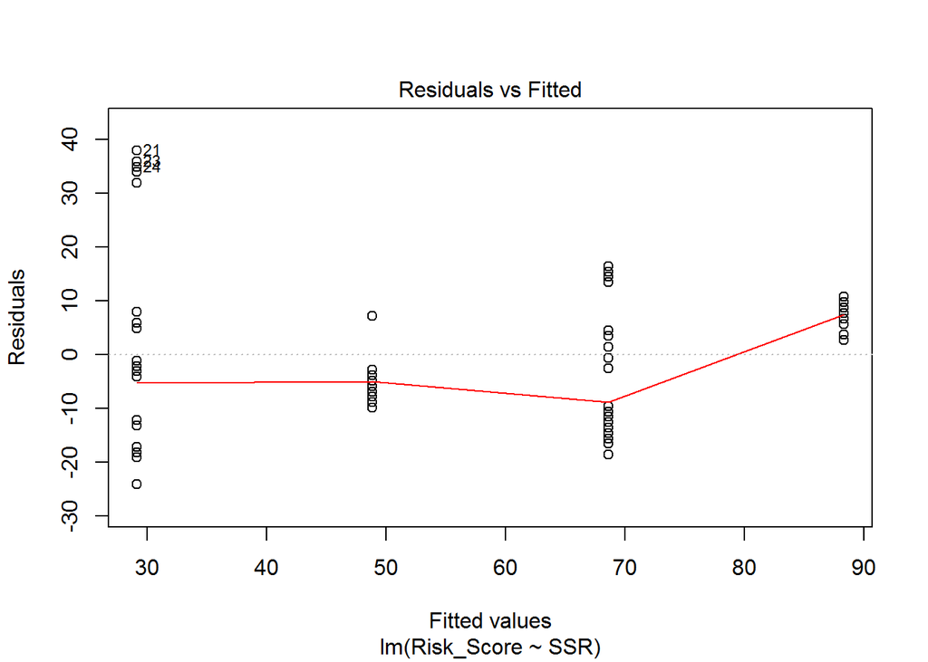

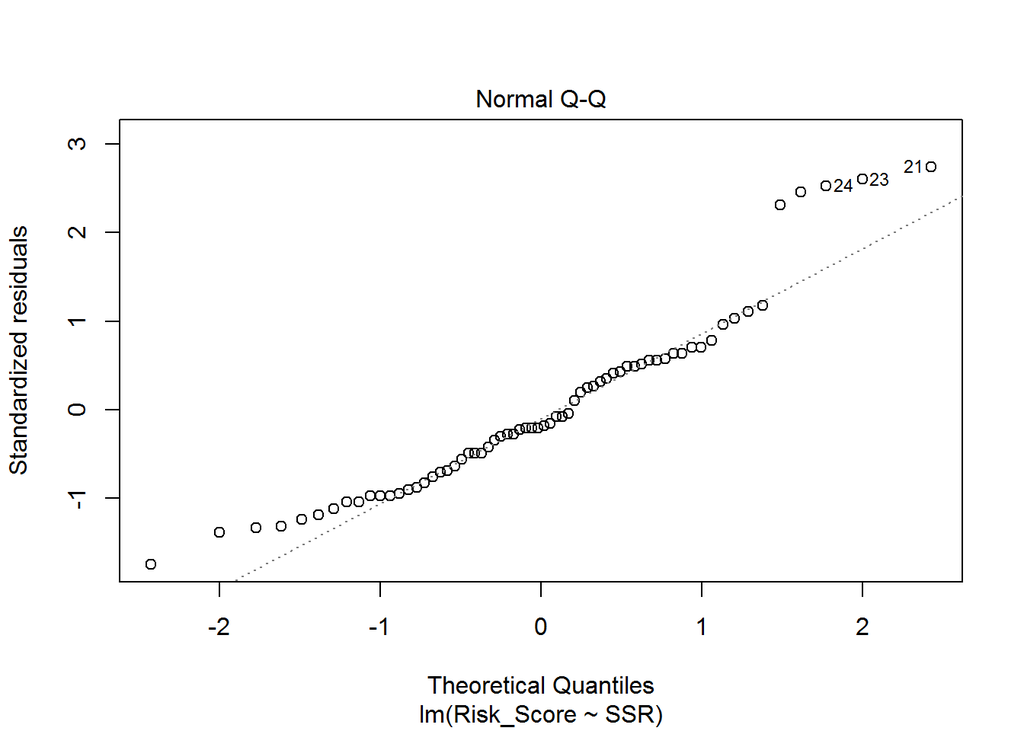

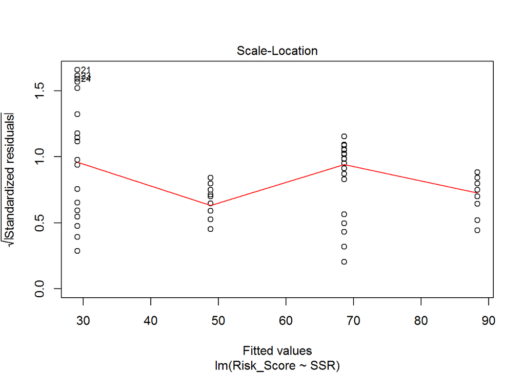

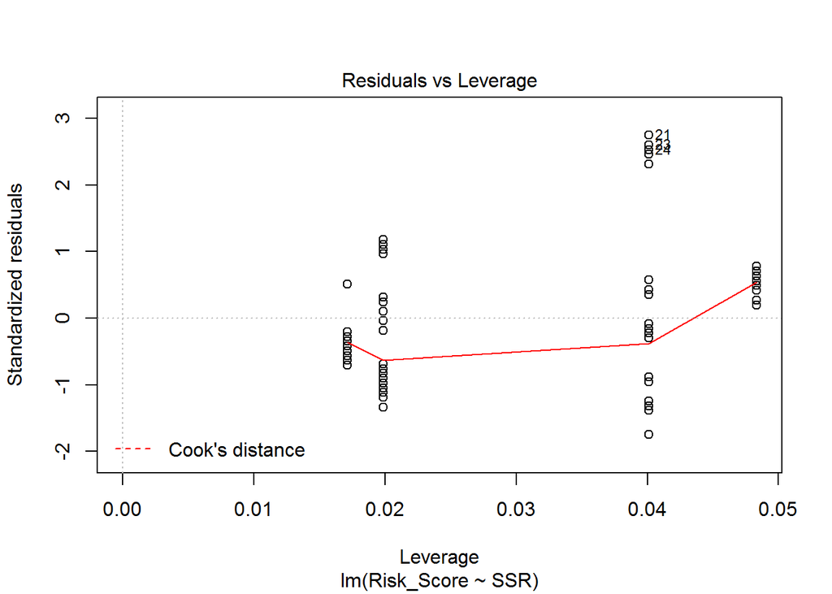

```r
plot(lm(Risk_Score~SSR, dat=bridges))
```

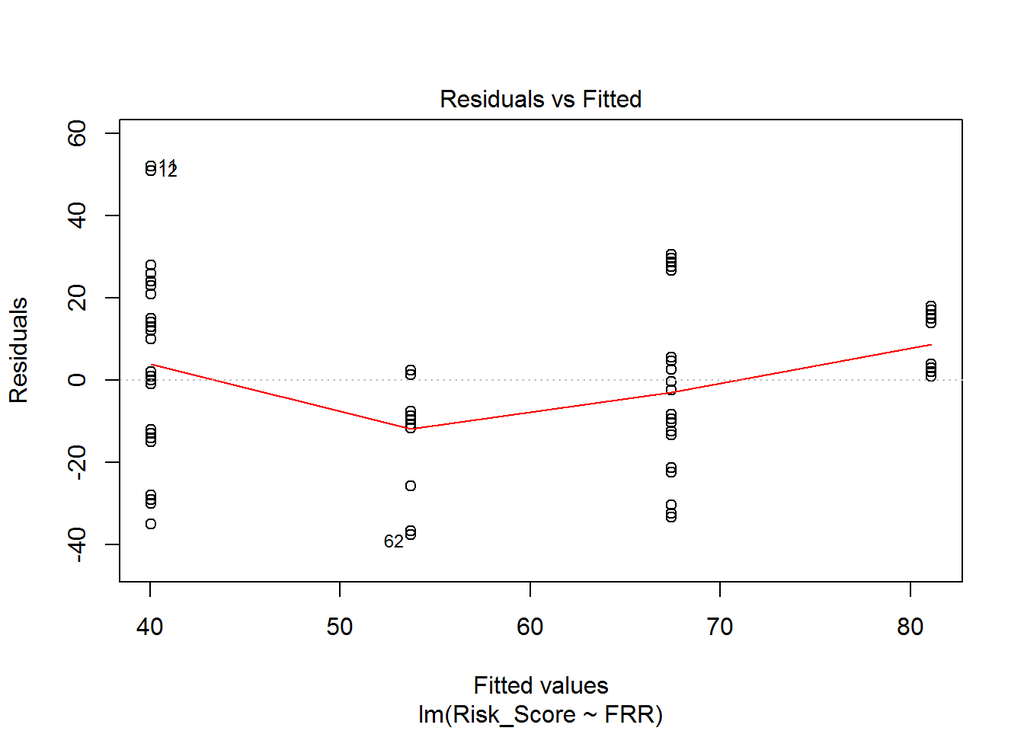

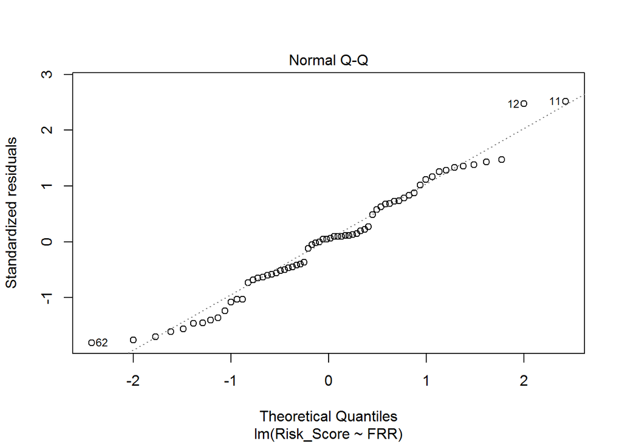

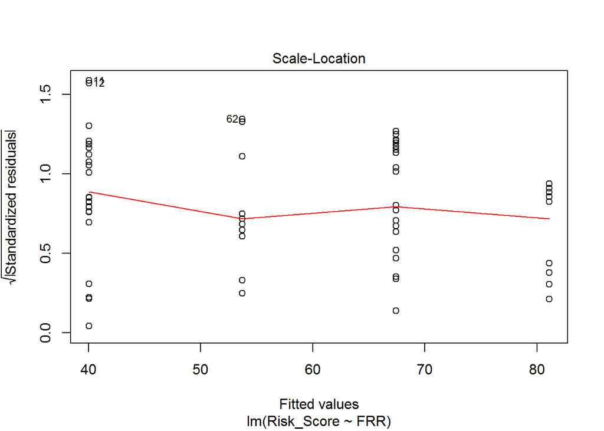

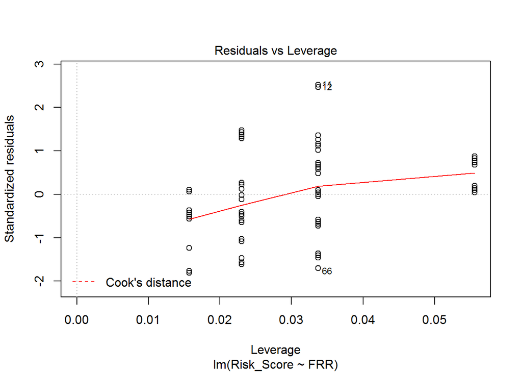

```r
plot(lm(Risk_Score~FRR, dat=bridges))
```

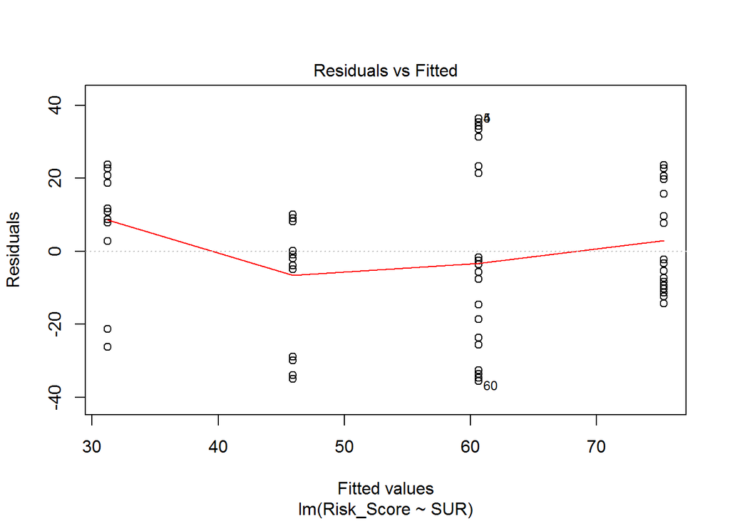

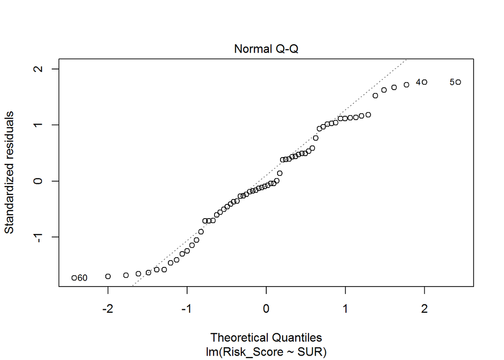

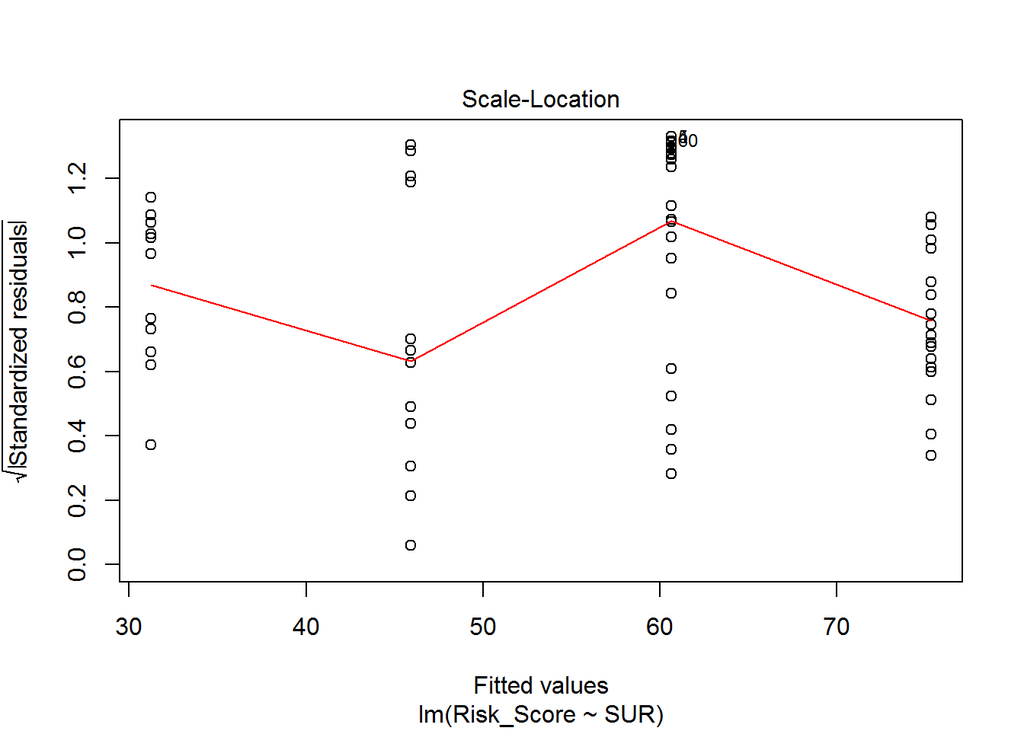

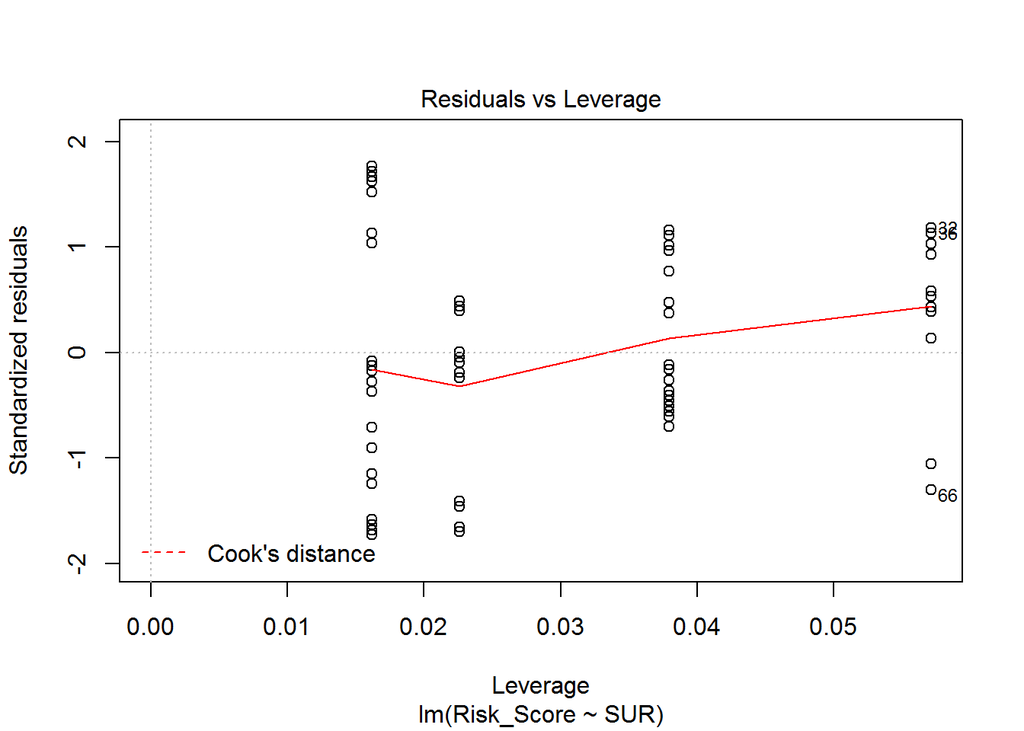

```r
plot(lm(Risk_Score~SUR, dat=bridges))
```

The model that best fits the data is the full model (fullmod), when all predictors are factored into the model and its interactions. Removing ERR and interactions, however, does not change the R^2 value very much, and including ERR and interactions might result in overfitting.

# d) Which linear regression model provides the best predictive accuracy?

The most accurate prediction model will be the one with the lowest MSE.

Author’s Note (edited 5 days since assignemt was turned in): cross-validation methods were not yet discussed in class, so what I did below was an unequal hold-out validation. There are 66 observations (N=66), and 40 of those were used to train models while the remaining 26 were used to test them.

Due to the loss of information when omitting 26 observations for training, and due to the high variability of the hold-out method of validation, the MSE’s below are not optimal and may not be reproducible.

```r
training_data = bridges[1:40,]
testing_data = bridges[-1:-40,]

model1 <- lm(Risk_Score~SSR+FRR+SUR+SSR*FRR*SUR, dat=training_data)
model2 <- lm(Risk_Score~SSR+FRR+SUR+SSR*FRR+SSR*SUR+FRR*SUR, dat=training_data)
model3 <- lm(Risk_Score~SSR+FRR+SUR+SSR*FRR+SSR*SUR, dat=training_data)
model4 <- lm(Risk_Score~SSR+FRR+SUR+SSR*FRR+FRR*SUR,  dat=training_data)
model5 <- lm(Risk_Score~SSR+FRR+SUR+SSR*SUR+FRR*SUR,  dat=training_data)
model6 <- lm(Risk_Score~SSR+FRR+SUR+SSR*FRR, dat=training_data)
model7 <- lm(Risk_Score~SSR+FRR+SUR+SSR*SUR, dat=training_data)
model8 <- lm(Risk_Score~SSR+FRR+SUR+FRR*SUR, dat=training_data)
model9 <- lm(Risk_Score~SSR+FRR+SUR, dat=training_data)
model10 <- lm(Risk_Score~SSR+FRR+SSR*FRR, dat=training_data)
model11 <- lm(Risk_Score~SSR+SUR+SSR*SUR, dat=training_data)
model12 <- lm(Risk_Score~FRR+SUR+FRR*SUR, dat=training_data)
model13 <- lm(Risk_Score~SSR+FRR, dat=training_data)
model14 <- lm(Risk_Score~SSR+SUR, dat=training_data)
model15 <- lm(Risk_Score~SSR, dat=training_data)
model16 <- lm(Risk_Score~FRR, dat=training_data)
model17 <- lm(Risk_Score~SUR, dat=training_data)

y = testing_data$Risk_Score


y_hat1=predict(model1, testing_data[,-5])
y_hat2=predict(model2, testing_data[,-5])
y_hat3=predict(model3, testing_data[,-5])
y_hat4=predict(model4, testing_data[,-5])
y_hat5=predict(model5, testing_data[,-5])
y_hat6=predict(model6, testing_data[,-5])
y_hat7=predict(model7, testing_data[,-5])
y_hat8=predict(model8, testing_data[,-5])
y_hat9=predict(model9, testing_data[,-5])
y_hat10=predict(model10, testing_data[,-5])
y_hat11=predict(model11, testing_data[,-5])
y_hat12=predict(model12, testing_data[,-5])
y_hat13=predict(model13, testing_data[,-5])
y_hat14=predict(model14, testing_data[,-5])
y_hat15=predict(model15, testing_data[,-5])
y_hat16=predict(model16, testing_data[,-5])
y_hat17=predict(model17, testing_data[,-5])



MSE1=mean((y-y_hat1)^2)
MSE2=mean((y-y_hat2)^2)
MSE3=mean((y-y_hat3)^2)
MSE4=mean((y-y_hat4)^2)
MSE5=mean((y-y_hat5)^2)
MSE6=mean((y-y_hat6)^2)
MSE7=mean((y-y_hat7)^2)
MSE8=mean((y-y_hat8)^2)
MSE9=mean((y-y_hat9)^2)
MSE10=mean((y-y_hat10)^2)
MSE11=mean((y-y_hat11)^2)
MSE12=mean((y-y_hat12)^2)
MSE13=mean((y-y_hat13)^2)
MSE14=mean((y-y_hat14)^2)
MSE15=mean((y-y_hat15)^2)
MSE16=mean((y-y_hat16)^2)
MSE17=mean((y-y_hat17)^2)


MSE1
```

```
## [1] 191.727
```

```r
MSE2
```

```
## [1] 195.2083
```

```r
MSE3
```

```
## [1] 191.8597
```

```r
MSE4
```

```
## [1] 267.1297
```

```r
MSE5
```

```
## [1] 231.5051
```

```r
MSE6
```

```
## [1] 278.3896
```

```r
MSE7
```

```
## [1] 230.6406
```

```r
MSE8
```

```
## [1] 195.1549
```

```r
MSE9
```

```
## [1] 205.1535
```

```r
MSE10
```

```
## [1] 683.3952
```

```r
MSE11
```

```
## [1] 263.497
```

```r
MSE12
```

```
## [1] 918.57
```

```r
MSE13
```

```
## [1] 543.7472
```

```r
MSE14
```

```
## [1] 199.574
```

```r
MSE15
```

```
## [1] 586.533
```

```r
MSE16
```

```
## [1] 1296.894
```

```r
MSE17
```

```
## [1] 1180.92
```

The model with the lowest MSE is Model 1, the model with SSR+FRR+SUR+interactions among the 3. Although we decided on the model with SSR+FRR+SUR (model 9), we did not previously consider the interaction between SSR, FRR, and SUR.

**However**, the regression analysis in part b) suggested that the interaction among all 3 is insignificant, and that the only interaction pair that was significant was SSR:SUR. Nevertheless, the MSE for model 16 (FRR only) was very high, so there must be something about FRR that increases the MSE and decreases the accuracy when the 3 variables are combined in the model.